# Peer Assignment 1

GMC

Sunday, February 15, 2015

# Introduction

It is now possible to collect a large amount of data about personal movement using activity monitoring devices such as a Fitbit, Nike Fuelband, or Jawbone Up. These type of devices are part of the “quantified self” movement - a group of enthusiasts who take measurements about themselves regularly to improve their health, to find patterns in their behavior, or because they are tech geeks. But these data remain under-utilized both because the raw data are hard to obtain and there is a lack of statistical methods and software for processing and interpreting the data.

This assignment makes use of data from a personal activity monitoring device. This device collects data at 5 minute intervals through out the day. The data consists of two months of data from an anonymous individual collected during the months of October and November, 2012 and include the number of steps taken in 5 minute intervals each day.

## Loading and preprocessing the data

Data was read and processed using the following code (assuming the file is in your R working directory):

```r
activity <- read.csv("activity.csv", stringsAsFactors=FALSE)
# Convert date to a proper format
activity$date <- as.Date(activity$date)
```

## What is mean total number of steps taken per day?

We will store in *byDay* the total of steps for each day.

We then plot a histogram with that data.

Finally, we calculate both the mean and the median.

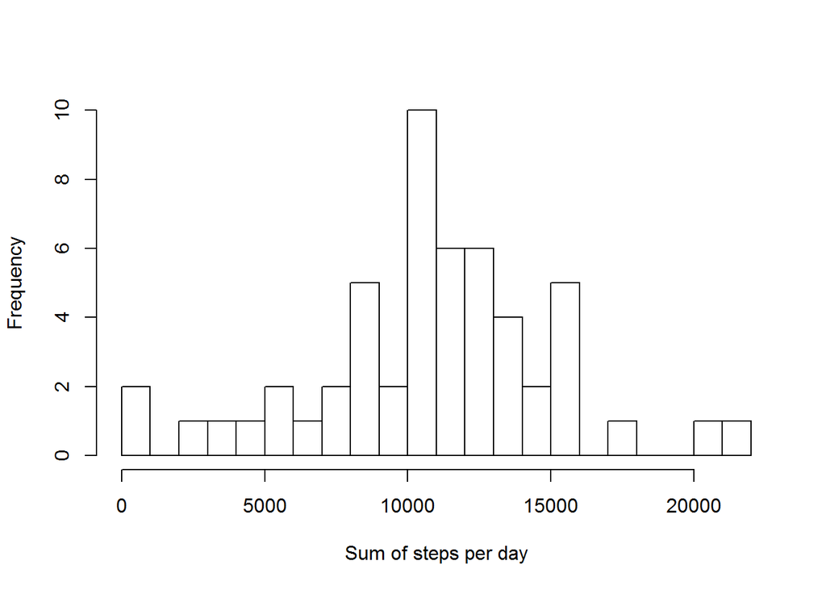

```r
byDay <- tapply(activity$steps, activity$date, sum)
hist(byDay, 20, xlab = "Sum of steps per day", main ="")
```

```r
mean(byDay, na.rm = TRUE)
```

```
## [1] 10766.19
```

```r
median(byDay, na.rm = TRUE)
```

```
## [1] 10765
```

## What is the average daily activity pattern?

We store in *byActivity* the mean of steps by 5 minute interval of day. A plot is made with this data.

Finally, we present the 5-minute with the highest number of steps.

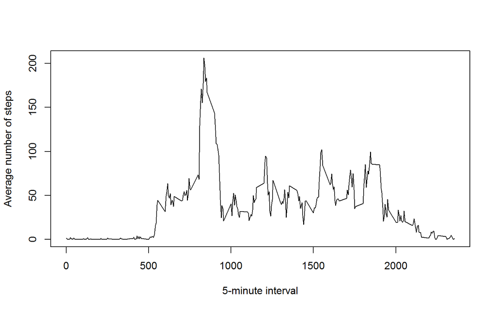

```r
byActivity <-tapply(activity$steps, activity$interval, mean, na.rm = TRUE)
plot(names(byActivity), byActivity, type = "l", xlab = "5-minute interval", main = "", ylab = "Average number of steps")
```

```r
byActivity[byActivity == max(byActivity)]
```

```
##      835
## 206.1698
```

## Inputing missing values

We first calculate the total number of missing values (NA).

Then, we build a new dataframe, *activityFilled*, using the mean of the 5-minute interval. We also show that this new dataframe has no NA.

```r
sum(is.na(activity))
```

```
## [1] 2304
```

```r
activityFilled <- activity
activityFilled[which(is.na(activityFilled$steps)), 1] <- byActivity[as.character(activityFilled[which(is.na(activityFilled$steps)), 3])]
sum(is.na(activityFilled))
```

```
## [1] 0
```

Now, let’s repeat the previous analysis with this new dataframe:

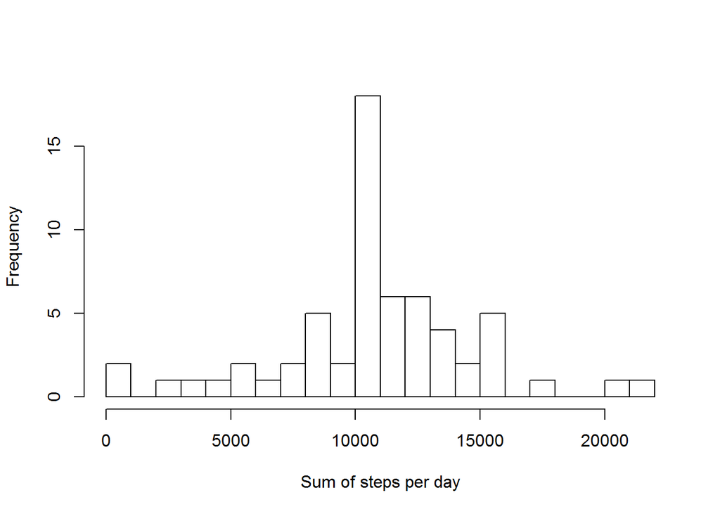

```r
byDay <- tapply(activityFilled$steps,activityFilled$date, sum)
hist(byDay, 20, xlab = "Sum of steps per day", main ="")
```

```r
mean(byDay)
```

```
## [1] 10766.19
```

```r
median(byDay)
```

```
## [1] 10766.19
```

Only the median is slightly changed.

## Are there differences in activity patterns between weekdays and weekends?

We start by adding another column to *activity*, to signal a weekday or a weekend. Notice that in my computer I had to write the weekdays in my language for the system to accept them. We then fill it with the appropriate value. Next, we produce subsets with the data for weekends and weekdays, and plot graphs accordingly.

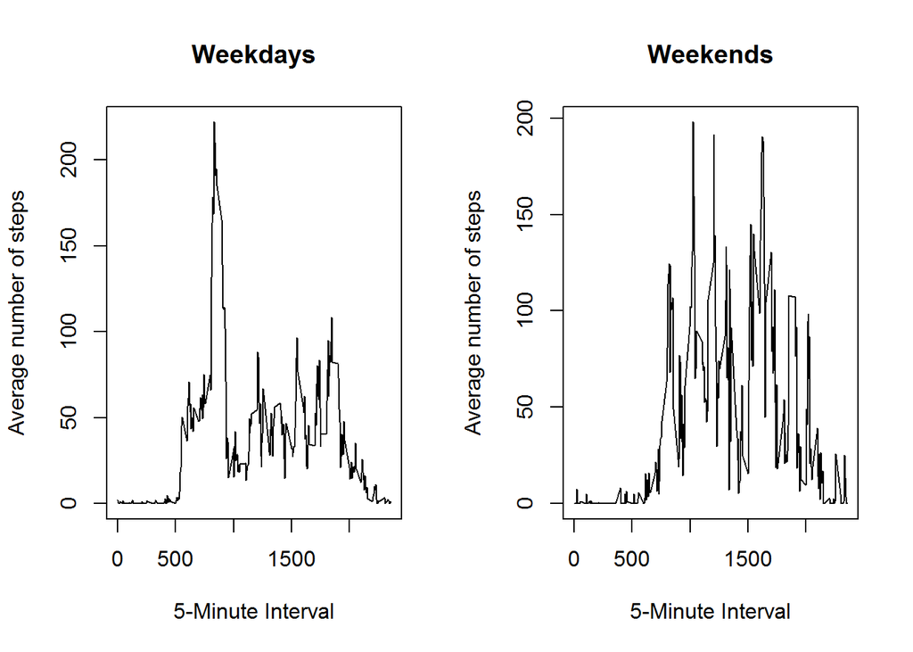

```r
activity$day <- as.factor(c("weekend", "weekday"))
activity[weekdays(activity$date) == "s??bado" | weekdays(activity$date) == "domingo" , 4] <- factor("weekend")
activity[!(weekdays(activity$date) == "s??bado" | weekdays(activity$date) == "domingo"), 4] <- factor("weekday")
weekends <- subset(activity, day == "weekend")
weekdays <- subset(activity, day == "weekday")
act_weekends <- tapply(weekends$steps, weekends$interval, mean, na.rm = TRUE)
act_weekdays <- tapply(weekdays$steps, weekdays$interval, mean, na.rm = TRUE)
par(mfrow=c(1,2))
plot(names(act_weekdays), act_weekdays, type = "l", xlab = "5-Minute Interval",
     main = "Weekdays", ylab = "Average number of steps")
plot(names(act_weekends), act_weekends, type = "l", xlab = "5-Minute Interval",
     main = "Weekends", ylab = "Average number of steps")
```

During weekends the activity is more spread in time.